# Changes on CRAN

2024-07-01 to 2024-09-30

Kurt Hornik

WU Wirtschaftsuniversität Wien  
Kurt.Hornik@R-project.org

Uwe Ligges

TU Dortmund  
Uwe.Ligges@R-project.org

Achim Zeileis

Universität Innsbruck  
Achim.Zeileis@R-project.org

# CRAN growth

In the past 3 months, 473 new packages were added to the CRAN package repository. 144 packages were unarchived, 207 were archived and 1 had to be removed. The following shows the growth of the number of active packages in the CRAN package repository:

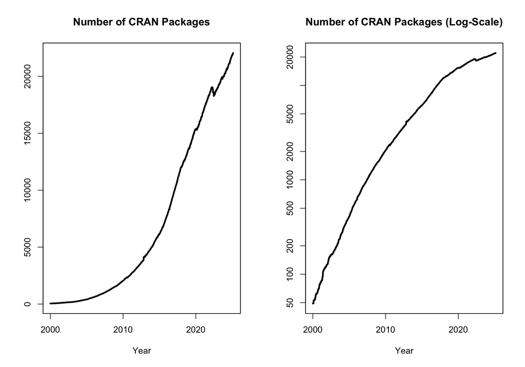

# Changes in the CRAN Repository Policy

Similar to providing ORCID identifiers for individual authors and contributors in R packages, the policy now encorages to provide ROR identifiers (from the Research Organization Registry, https://ror.org/) in a package’s `DESCRIPTION` file in case there are organizations among the authors and contributors.

The policy now points out explicitly that package names on CRAN are persistent and in general it is not permitted to change a package’s name.

# CRAN package submissions

From July 2024 to September 2024 CRAN received 6705 package submissions. For these, 10875 actions took place of which 7759 (71%) were auto processed actions and 3116 (29%) manual actions.

Minus some special cases, a summary of the auto-processed and manually triggered actions follows:

|  | archive | inspect | newbies | pending | pretest | publish | recheck | waiting |
| --- | --- | --- | --- | --- | --- | --- | --- | --- |
| auto | 2184 | 724 | 1459 | 219 | 0 | 2001 | 736 | 364 |
| manual | 1255 | 22 | 24 | 49 | 63 | 1282 | 351 | 58 |

These include the final decisions for the submissions which were

|  | archive | publish |
| --- | --- | --- |
| auto | 2046 (31.2%) | 1717 (26.2%) |
| manual | 1235 (18.8%) | 1564 (23.8%) |

where we only count those as *auto* processed whose publication or rejection happened automatically in all steps.

# CRAN mirror security

Currently, there are 94 official CRAN mirrors, 73 of which provide both secure downloads via ‘`https`’ *and* use secure mirroring from the CRAN master (via rsync through ssh tunnels). Since the R 3.4.0 release, `chooseCRANmirror()` offers these mirrors in preference to the others which are not fully secured (yet).

# CRAN Task View Initiative

There is one new task view:

- [Dynamic Visualizations and Interactive Graphics](https://CRAN.R-project.org/view=DynamicVisualizations): Maintained by Sherry Zhang, Dianne Cook, Ian Lyttle.

Currently there are 46 task views (see https://CRAN.R-project.org/web/views/), with median and mean numbers of CRAN packages covered 110 and 123, respectively. Overall, these task views cover 4741 CRAN packages, which is about 21% of all active CRAN packages.